# **Homework_Week3**

Shivani

# 1 Contents

1. Accessing and saving data
2. Tidying data
3. Visualising Data
4. More Visualisations

To produce a short Rmarkdown document involving the process of loading, cleaning, and visualizing the BreedingPairs data in this data set.

```r
#vroom-ing data to access it from git-hub
library(vroom)
Breeding_Pair <- vroom("https://raw.githubusercontent.com/ExperimentalConservation/Bioinformatics_data/master/Workshop%203/wader_data.csv")
```

## 1.1 Accessing and saving data

Accessing the file into R using knitr package

```r
#loading the knitr package
library(knitr)
Breeding_Pair<- read.csv("C:\\Users\\fe24041\\OneDrive - University of Bristol\\Documents\\R_programming\\Week 3\\Breeding_Pair.csv")

#using kable function from the knitr package to generate table
kable(Breeding_Pair)
```

| Year | BreedingPairs | AvgMass | SDMass |
| --- | --- | --- | --- |
| 1984 | 391 | 541.2 | 34.7 |
| 1985 | 420 | 536.3 | 36.5 |
| 1986 | 429 | 528.7 | 37.8 |
| 1987 | 418 | 542.2 | 38.5 |
| 1988 | 423 | 531.1 | 31.9 |
| 1989 | 406 | 524.1 | 40.2 |
| 1990 | 401 | 531.0 | 37.2 |
| 1991 | 427 | 528.4 | 53.1 |
| 1992 | 407 | 528.4 | 35.7 |
| 1993 | NA | 526.9 | 40.3 |
| 1994 | 407 | 542.1 | 36.4 |
| 1995 | 390 | 538.3 | 41.3 |
| 1996 | 268 | NA | 39.2 |
| 1997 | 223 | 539.7 | 43.7 |
| 2998 | 229 | 517.1 | 50.5 |
| 1999 | 218 | 536.3 | 36.2 |
| 2000 | NA | 539.4 | 41.7 |
| 2001 | 221 | 509.4 | 41.2 |
| 2002 | NA | 529.4 | 38.3 |
| 2003 | 176 | 539.5 | 43.0 |
| 2004 | 162 | 533.6 | 33.1 |
| 2005 | 167 | 541.3 | 39.0 |
| 2006 | 152 | 532.4 | 31.1 |
| 2007 | 148 | 533.3 | 28.1 |
| 2008 | NA | 539.1 | 38.2 |
| 2009 | 120 | 526.9 | 34.1 |
| 2010 | 122 | 533.4 | 33.0 |
| 2011 | 110 | 523.0 | 34.0 |
| 2012 | 102 | 531.2 | 34.3 |
| 2013 | 97 | 527.9 | 32.5 |
| 2014 | 92 | 515.5 | 36.3 |
| 2015 | 90 | 528.4 | 37.4 |
| 2016 | 83 | 543.5 | 61.9 |

## 1.2 Tidying data

Checking the structure of Breeding_Pair_data and summarising the data

```r
class(Breeding_Pair)
```

```
## [1] "data.frame"
```

```r
describe(Breeding_Pair)
```

```
## Breeding_Pair
##
##  4  Variables      33  Observations
## --------------------------------------------------------------------------------
## Year
##        n  missing distinct     Info     Mean      Gmd      .05      .10
##       33        0       33        1     2030    71.29     1986     1987
##      .25      .50      .75      .90      .95
##     1992     2001     2009     2014     2015
##
## lowest : 1984 1985 1986 1987 1988, highest: 2013 2014 2015 2016 2998
## --------------------------------------------------------------------------------
## BreedingPairs
##        n  missing distinct     Info     Mean      Gmd      .05      .10
##       29        4       28        1    251.7    152.2     90.8     96.0
##      .25      .50      .75      .90      .95
##    122.0    221.0    406.0    420.6    425.4
##
## lowest :  83  90  92  97 102, highest: 418 420 423 427 429
## --------------------------------------------------------------------------------
## AvgMass
##        n  missing distinct     Info     Mean      Gmd      .05      .10
##       32        1       28    0.999    531.8    9.183    516.4    523.1
##      .25      .50      .75      .90      .95
##    528.3    531.8    539.2    541.3    542.1
##
## lowest : 509.4 515.5 517.1 523   524.1, highest: 541.2 541.3 542.1 542.2 543.5
## --------------------------------------------------------------------------------
## SDMass
##        n  missing distinct     Info     Mean      Gmd      .05      .10
##       33        0       33        1     38.5    6.698    31.58    32.60
##      .25      .50      .75      .90      .95
##    34.30    37.40    40.30    43.56    51.54
##
## lowest : 28.1 31.1 31.9 32.5 33  , highest: 43   43.7 50.5 53.1 61.9
## --------------------------------------------------------------------------------
```

Removing missing values from the data using drop_na() function

```r
Breeding_Pair_na <-
  #taking original data set
  Breeding_Pair %>%
  #filtering out any values equal to NA
  drop_na(BreedingPairs, AvgMass)
kable(Breeding_Pair_na)
```

| Year | BreedingPairs | AvgMass | SDMass |
| --- | --- | --- | --- |
| 1984 | 391 | 541.2 | 34.7 |
| 1985 | 420 | 536.3 | 36.5 |
| 1986 | 429 | 528.7 | 37.8 |
| 1987 | 418 | 542.2 | 38.5 |
| 1988 | 423 | 531.1 | 31.9 |
| 1989 | 406 | 524.1 | 40.2 |
| 1990 | 401 | 531.0 | 37.2 |
| 1991 | 427 | 528.4 | 53.1 |
| 1992 | 407 | 528.4 | 35.7 |
| 1994 | 407 | 542.1 | 36.4 |
| 1995 | 390 | 538.3 | 41.3 |
| 1997 | 223 | 539.7 | 43.7 |
| 2998 | 229 | 517.1 | 50.5 |
| 1999 | 218 | 536.3 | 36.2 |
| 2001 | 221 | 509.4 | 41.2 |
| 2003 | 176 | 539.5 | 43.0 |
| 2004 | 162 | 533.6 | 33.1 |
| 2005 | 167 | 541.3 | 39.0 |
| 2006 | 152 | 532.4 | 31.1 |
| 2007 | 148 | 533.3 | 28.1 |
| 2009 | 120 | 526.9 | 34.1 |
| 2010 | 122 | 533.4 | 33.0 |
| 2011 | 110 | 523.0 | 34.0 |
| 2012 | 102 | 531.2 | 34.3 |
| 2013 | 97 | 527.9 | 32.5 |
| 2014 | 92 | 515.5 | 36.3 |
| 2015 | 90 | 528.4 | 37.4 |
| 2016 | 83 | 543.5 | 61.9 |

## 1.3 Visualising Data

Let’s visualize the trend of number of breeding pairs over the year

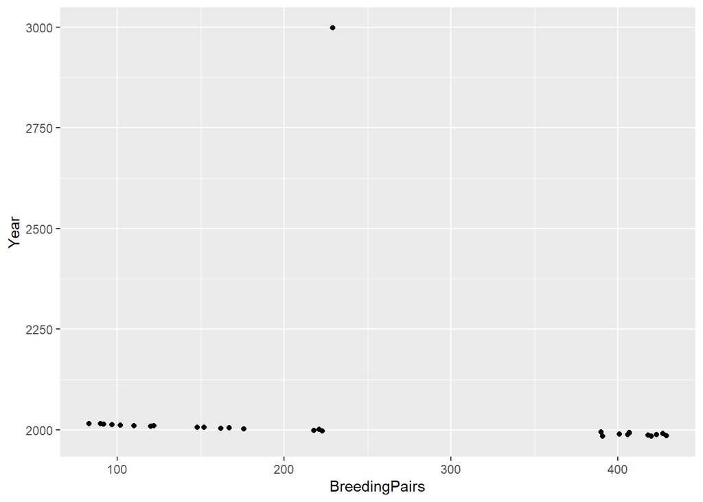

```r
#making a ggplot
ggplot(Breeding_Pair_na, aes(x=BreedingPairs, y= Year))+
  #adding a geom point
  geom_point()
```

Looking at the plot there is abnormality in the year (2998 doesn’t seem right). Let’s filter out 2998 from the year column and re-plot with new data set.

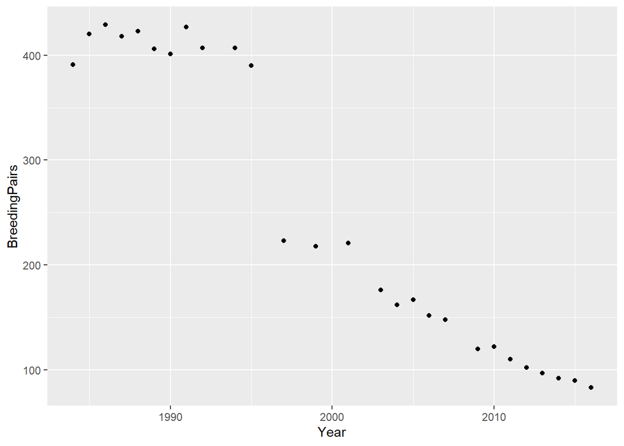

```r
#filtering and removing data for the year 2998
Breeding_Pair_new <-
  Breeding_Pair_na %>%
  filter(Year != 2998)

#plotting Breeding pair vs Year for the new filtered of data
ggplot(Breeding_Pair_new, aes(x=Year, y=BreedingPairs))+
  geom_point()
```

## 1.4 More Visualizations

Same data Breeding pair vs Year represented as a geom smooth plot.

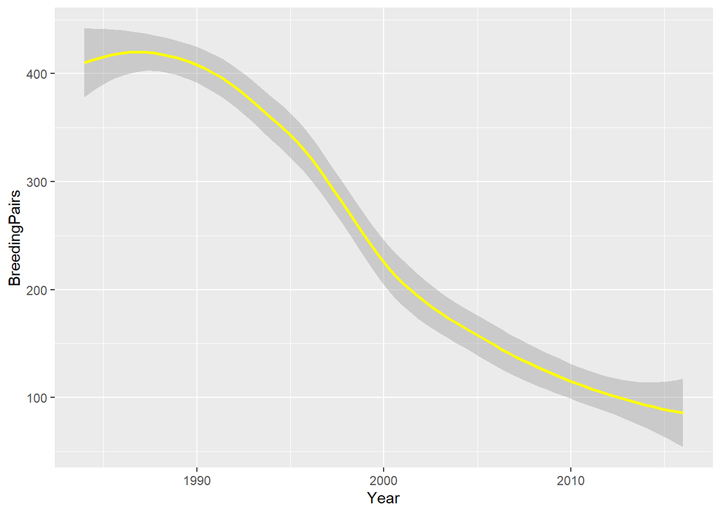

```r
ggplot(data = Breeding_Pair_new, aes(x = Year, y = BreedingPairs)) +
  geom_smooth(col = "Yellow")
```

From above plots we can see a decline in number of Breeding pairs over the years 1984 to 2016.

Now let’s consider the relationship between declining number of breedingpairs with their average mass.

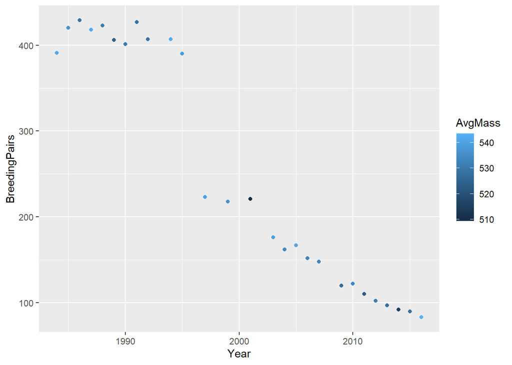

```r
P <- ggplot(data = Breeding_Pair_new, aes(x = Year, y = BreedingPairs))

#adding the graphics
P <- P + geom_point(aes(col=AvgMass))

# view the plot
P
```

Now let’s consider the trend of average mass over the years

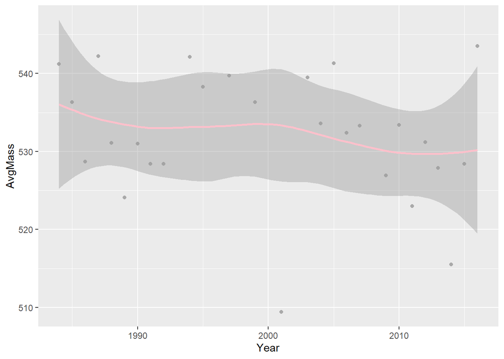

```r
ggplot(data = Breeding_Pair_new, aes(x = Year, y = AvgMass)) +
  ## points
  geom_point(col = "darkgrey") +
  ## and lines!
  geom_smooth(col = "pink")
```

From the above plot we can see there is no much variation in average mass over the period (500-550)